# Beyond the AUC: evaluating a clinical prediction model in R

OMARI Seminar Series · companion code and live demo

Author

Steven Hawken

Published

October 28, 2026

**These are simulated data**

Every number in this document comes from **simulated** data. The design (clinical covariates plus ~30 newborn screening analytes, a large development cohort and two smaller external sites) is loosely inspired by published work on estimating gestational age (GA) from newborn screening. The relationships and parameter values are invented, so the results here **do not reproduce** any published study. For the real results, see the references at the end.

# 1 Setup

```r
# install.packages(c("dplyr", "ggplot2", "glmnet", "ranger"))
library(dplyr)
library(ggplot2)
library(glmnet)
library(splines)

source("R/simulate_data.R")   # data-generating mechanism
source("R/fit_models.R")      # feature construction + model fitting
source("R/metrics.R")         # performance measures, written out in base R
source("R/plots.R")           # shared ggplot helpers

options(width = 200)
pct <- function(x, d = 1) sprintf(paste0("%.", d, "f%%"), 100 * x)
```

## 1.1 The data

Three cohorts. Because the data are simulated, each infant has both a **true GA** and a **reference GA**: the value a dating ultrasound would record, which includes measurement error. Real studies only ever see the reference.

```r
if (!file.exists("data/sim_dev.csv")) simulate_all("data")
dev   <- read.csv("data/sim_dev.csv")
siteA <- read.csv("data/sim_siteA.csv")
siteB <- read.csv("data/sim_siteB.csv")

bind_rows(dev, siteA, siteB) |>
  group_by(site) |>
  summarise(n = n(),
            `Preterm (reference)` = pct(mean(preterm)),
            `Preterm (true)` = pct(mean(preterm_true)),
            `SGA` = pct(mean(sga)),
            `Mean birthweight (g)` = round(mean(bw)),
            `Dating US at 9-13 wk` = pct(mean(us_timing == "9-13 wk"), 0))
```

| site | n | Preterm (reference) | Preterm (true) | SGA | Mean birthweight (g) | Dating US at 9-13 wk |
| --- | --- | --- | --- | --- | --- | --- |
| dev | 60000 | 8.4% | 7.8% | 11.1% | 3500 | 100% |
| siteA | 1500 | 12.3% | 11.6% | 29.9% | 3201 | 100% |
| siteB | 1000 | 18.6% | 14.2% | 21.5% | 3245 | 15% |

What differs between the sites (by design):

|  | Development | External site A | External site B |
| --- | --- | --- | --- |
| Population | Reference population | Smaller for GA (more SGA), more preterm | Smaller for GA, more preterm |
| Laboratory | Reference lab | Different calibration for 6 analytes | Different calibration for 5 analytes |
| Reference standard | First-trimester ultrasound | First-trimester ultrasound | **Mostly 2nd/3rd-trimester ultrasound** |

# 2 The case model, in brief

We split the development cohort 2/3 for training and 1/3 for testing, then fit:

- **Clinical only:** sex, multiple birth, birthweight (natural spline), fitted by OLS
- **Full:** clinical + 30 log-analytes + their squares + age at collection, fitted by elastic net (α = 0.5, λ chosen by 10-fold cross-validation)
- two comparators used later: a **random forest** and a deliberately **overfitted** unpenalised regression fitted on only 200 infants

```r
if (file.exists("output/fit.rds")) {
  res <- readRDS("output/fit.rds")
} else {
  res <- fit_all(dev, siteA, siteB)
  saveRDS(res, "output/fit.rds")
}
m3 <- res$models$m3
cat("Non-zero coefficients in the full model:",
    sum(coef(m3, s = "lambda.min") != 0) - 1, "of", nrow(coef(m3)) - 1, "\n")
```

```
Non-zero coefficients in the full model: 65 of 67
```

The evaluation below uses only four columns: the reference GA (`ga_ref`), the predictions (`pred_*`), and a preterm indicator. **Everything that follows could be done for any model, however it was built.**

# 3 Performance for a continuous outcome

## 3.1 Overall accuracy

```r
sites <- c(test = "Development (test)", siteA = "External site A",
           siteB = "External site B")

cont_tab <- bind_rows(lapply(names(sites), function(s) {
  d <- res[[s]]
  bind_rows(
    cbind(site = sites[[s]], model = "Clinical only",
          cont_metrics(d$ga_ref, d$pred_m1)),
    cbind(site = sites[[s]], model = "Full",
          cont_metrics(d$ga_ref, d$pred_m3)))
}))

cont_tab |>
  mutate(across(c(bias_wk, MAE_wk, RMSE_wk, R2, cal_slope), \(x) round(x, 2)),
         across(c(within_7d, within_14d), pct)) |>
  select(site, model, n, bias_wk, MAE_wk, RMSE_wk, R2, within_7d, within_14d,
         cal_slope)
```

| site | model | n | bias_wk | MAE_wk | RMSE_wk | R2 | within_7d | within_14d | cal_slope |
| --- | --- | --- | --- | --- | --- | --- | --- | --- | --- |
| Development (test) | Clinical only | 20000 | 0.02 | 0.94 | 1.19 | 0.62 | 61.1% | 91.2% | 0.98 |
| Development (test) | Full | 20000 | 0.02 | 0.70 | 0.88 | 0.79 | 74.7% | 97.7% | 1.00 |
| External site A | Clinical only | 1500 | -0.48 | 1.08 | 1.35 | 0.60 | 53.5% | 86.1% | 0.95 |
| External site A | Full | 1500 | -0.27 | 0.77 | 0.95 | 0.80 | 69.9% | 96.4% | 0.98 |
| External site B | Clinical only | 1000 | -0.20 | 1.41 | 1.80 | 0.48 | 44.0% | 75.2% | 1.00 |
| External site B | Full | 1000 | -0.09 | 1.18 | 1.52 | 0.64 | 52.9% | 82.2% | 1.02 |

**Reading the table**

- **MAE** is the typical error in weeks: 0.7 weeks is about ±5 days.
- **Bias** (mean predicted − reference) is *calibration-in-the-large* for a continuous outcome. At site A the model **underestimates** GA on average.
- **% within 7/14 days** is often the most meaningful number for clinicians.
- The **calibration slope** (regressing reference on predicted) is close to 1 everywhere: predictions are not systematically too extreme or too moderate.

## 3.2 Calibration: observed against predicted

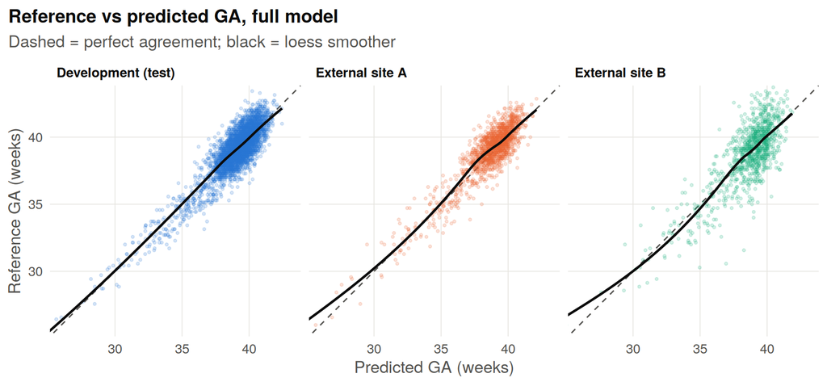

```r
long <- stack_sites(res)
plot_cont_calibration(long) +
  labs(title = "Reference vs predicted GA, full model",
       subtitle = "Dashed = perfect agreement; black = loess smoother")
```

## 3.3 “The model overestimates GA in preterm infants”. Is it miscalibrated?

This pattern appears in almost every GA-dating paper. Look at the errors in two different ways:

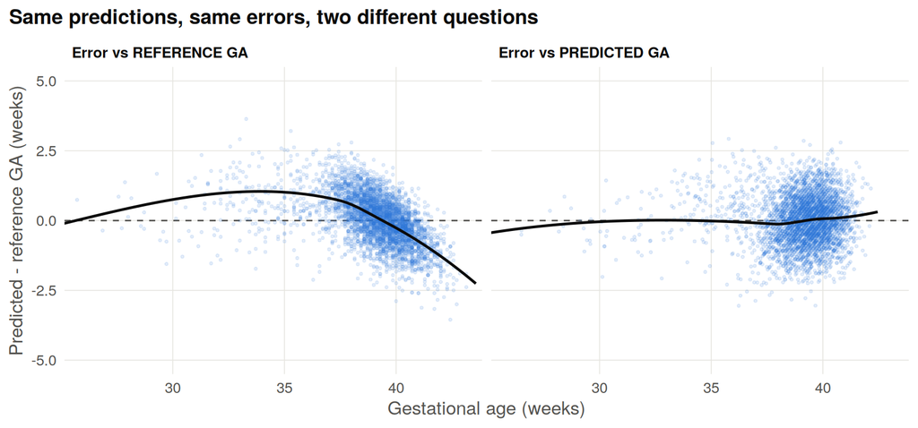

```r
plot_regression_to_mean(res$test) +
  labs(title = "Same predictions, same errors, two different questions")
```

- **Left:** among infants who *were* born at 30 weeks, the predictions are too high on average. That is **regression to the mean**, and any model with R² < 1 shows it.
- **Right:** among infants *predicted* to be 30 weeks, the average error is much closer to 0. **The model is broadly calibrated.** A small misfit remains in the sparse preterm range; we return to it in the section on class imbalance.

Calibration is judged conditional on the **prediction**, because that is what is available when the model is used. Subgroup analyses by true outcome status (such as “preterm infants”) answer a different question. It is a legitimate one, but it is not calibration.

```r
subgroup_tab <- function(d, label) {
  d |>
    mutate(group = case_when(preterm == 1 ~ "Preterm (<37 wk)",
                             sga == 1 ~ "Term, SGA",
                             TRUE ~ "Term, not SGA")) |>
    group_by(group) |>
    summarise(n = n(),
              `MAE clinical` = mean(abs(pred_m1 - ga_ref)),
              `MAE full` = mean(abs(pred_m3 - ga_ref)),
              `Bias full` = mean(pred_m3 - ga_ref), .groups = "drop") |>
    mutate(site = label, .before = 1)
}
bind_rows(subgroup_tab(res$test, "Development (test)"),
          subgroup_tab(res$siteA, "External site A")) |>
  mutate(across(where(is.double), \(x) round(x, 2)))
```

| site | group | n | MAE clinical | MAE full | Bias full |
| --- | --- | --- | --- | --- | --- |
| Development (test) | Preterm (<37 wk) | 1689 | 1.67 | 0.93 | 0.64 |
| Development (test) | Term, SGA | 1916 | 1.43 | 0.83 | -0.66 |
| Development (test) | Term, not SGA | 16395 | 0.80 | 0.66 | 0.03 |
| External site A | Preterm (<37 wk) | 184 | 1.38 | 0.87 | 0.27 |
| External site A | Term, SGA | 392 | 1.62 | 0.97 | -0.86 |
| External site A | Term, not SGA | 924 | 0.79 | 0.66 | -0.13 |

Among SGA infants, birthweight is misleading and the clinical-only model does badly. The analytes carry information about maturity that does not depend on size.

## 3.4 When the reference standard is the problem

Site B looks much worse than site A. But because the data are simulated, we can also score the predictions against the **true** GA:

```r
res$siteB |>
  group_by(`Dating ultrasound` = us_timing) |>
  summarise(n = n(),
            `MAE vs reference` = mean(abs(pred_m3 - ga_ref)),
            `MAE vs TRUE GA` = mean(abs(pred_m3 - ga_true))) |>
  bind_rows(res$siteB |>
              summarise(`Dating ultrasound` = "All", n = n(),
                        `MAE vs reference` = mean(abs(pred_m3 - ga_ref)),
                        `MAE vs TRUE GA` = mean(abs(pred_m3 - ga_true)))) |>
  mutate(across(where(is.double), \(x) round(x, 2)))
```

| Dating ultrasound | n | MAE vs reference | MAE vs TRUE GA |
| --- | --- | --- | --- |
| 14-24 wk | 510 | 1.07 | 0.62 |
| 9-13 wk | 154 | 0.81 | 0.67 |
| >24 wk | 336 | 1.52 | 0.60 |
| All | 1000 | 1.18 | 0.62 |

Against the truth the model is as accurate at site B as anywhere else. Most of the apparent loss of accuracy comes from a **noisier reference standard** (late ultrasounds), not from the model. In real data you never see the right column, so check it indirectly: restrict to infants with the best-quality reference, as in the Kenya validation.

# 4 Discrimination

## 4.1 From predicted GA to a risk of preterm birth

Net benefit and most classification metrics need a **predicted probability**. We map predicted GA to P(preterm) with a logistic model fitted in the **training** data only:

```r
link <- glm(preterm ~ pred_m3, family = binomial, data = res$train)
link1 <- glm(preterm ~ pred_m1, family = binomial, data = res$train)
for (s in c("test", "siteA", "siteB")) {
  res[[s]]$p_m3 <- predict(link,  newdata = res[[s]], type = "response")
  res[[s]]$p_m1 <- predict(link1, newdata = res[[s]], type = "response")
}
```

## 4.2 The AUC (c-statistic)

The AUC is the probability that a randomly chosen preterm infant gets a higher predicted risk than a randomly chosen term infant. It depends only on the **ranking** of the predictions.

```r
auc_row <- function(site, model, y, p) {
  ci <- auc_ci(y, p)
  data.frame(site = site, model = model, AUC = ci[["AUC"]],
             lower = ci[["lower"]], upper = ci[["upper"]])
}
bind_rows(lapply(names(sites), function(s) {
  d <- res[[s]]
  bind_rows(auc_row(sites[[s]], "Clinical only", d$preterm, d$p_m1),
            auc_row(sites[[s]], "Full", d$preterm, d$p_m3))
})) |>
  mutate(across(where(is.double), \(x) round(x, 3)))
```

| site | model | AUC | lower | upper |
| --- | --- | --- | --- | --- |
| Development (test) | Clinical only | 0.937 | 0.930 | 0.944 |
| Development (test) | Full | 0.981 | 0.978 | 0.984 |
| External site A | Clinical only | 0.937 | 0.918 | 0.956 |
| External site A | Full | 0.982 | 0.974 | 0.991 |
| External site B | Clinical only | 0.854 | 0.821 | 0.886 |
| External site B | Full | 0.909 | 0.884 | 0.934 |

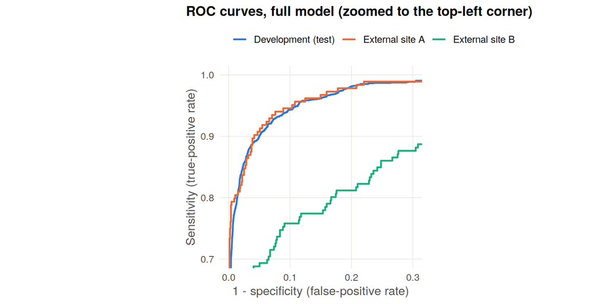

```r
roc_long <- bind_rows(lapply(names(sites), function(s) {
  cbind(roc_df(res[[s]]$preterm, res[[s]]$p_m3),
        site_lab = factor(sites[[s]], levels = sites))
}))
plot_roc(roc_long, "site_lab", COL_SITE, zoom = TRUE) +
  labs(title = "ROC curves, full model (zoomed to the top-left corner)")
```

Look at site B’s AUC. The same predictions scored against the **true** preterm status give:

```r
round(auc_ci(res$siteB$preterm_true, res$siteB$p_m3), 3)
```

```
  AUC lower upper
0.995 0.991 0.998
```

Misclassification in the reference standard **drags the AUC down**, even when the model is unchanged.

## 4.3 Thresholds, prevalence and the accuracy trap

```r
bind_rows(lapply(names(sites), function(s) {
  d <- res[[s]]
  bind_rows(cbind(site = sites[[s]], class_metrics(d$preterm, d$p_m3, 0.5)),
            cbind(site = sites[[s]], class_metrics(d$preterm, d$p_m3, 0.2)))
})) |>
  mutate(across(prevalence:accuracy, pct))
```

| site | threshold | prevalence | sensitivity | specificity | PPV | NPV | accuracy |
| --- | --- | --- | --- | --- | --- | --- | --- |
| Development (test) | 0.5 | 8.4% | 75.8% | 99.3% | 90.8% | 97.8% | 97.3% |
| Development (test) | 0.2 | 8.4% | 85.8% | 97.3% | 74.7% | 98.7% | 96.4% |
| External site A | 0.5 | 12.3% | 82.1% | 98.1% | 85.8% | 97.5% | 96.1% |
| External site A | 0.2 | 12.3% | 91.3% | 94.6% | 70.3% | 98.7% | 94.2% |
| External site B | 0.5 | 18.6% | 62.4% | 97.5% | 85.3% | 91.9% | 91.0% |
| External site B | 0.2 | 18.6% | 68.8% | 95.0% | 75.7% | 93.0% | 90.1% |

- **Sensitivity and specificity** describe the test. **PPV and NPV** describe the patient in front of you, and they change with prevalence. The sites differ in calibration as well as prevalence, so to isolate the effect of prevalence, hold the development-set sensitivity and specificity (threshold 0.2) fixed:

```r
cm <- class_metrics(res$test$preterm, res$test$p_m3, 0.2)
data.frame(prevalence = c(0.02, 0.05, 0.084, 0.15, 0.25)) |>
  mutate(PPV = cm$sensitivity * prevalence /
           (cm$sensitivity * prevalence + (1 - cm$specificity) * (1 - prevalence)),
         NPV = cm$specificity * (1 - prevalence) /
           (cm$specificity * (1 - prevalence) + (1 - cm$sensitivity) * prevalence),
         across(everything(), pct))
```

| prevalence | PPV | NPV |
| --- | --- | --- |
| 2.0% | 39.6% | 99.7% |
| 5.0% | 62.8% | 99.2% |
| 8.4% | 74.6% | 98.7% |
| 15.0% | 85.0% | 97.5% |
| 25.0% | 91.4% | 95.4% |

- A “model” that calls **every** infant term has an accuracy of 91.6% in the development test set. **Accuracy is not a useful summary when outcomes are imbalanced.**

## 4.4 Overall accuracy of the probabilities: the Brier score

```r
bind_rows(lapply(names(sites), function(s) {
  d <- res[[s]]
  bind_rows(cbind(site = sites[[s]], model = "Clinical only",
                  bin_metrics(d$preterm, d$p_m1)),
            cbind(site = sites[[s]], model = "Full",
                  bin_metrics(d$preterm, d$p_m3)))
})) |>
  select(site, model, prevalence, Brier, scaled_Brier) |>
  mutate(across(where(is.double), \(x) round(x, 3)))
```

| site | model | prevalence | Brier | scaled_Brier |
| --- | --- | --- | --- | --- |
| Development (test) | Clinical only | 0.084 | 0.035 | 0.545 |
| Development (test) | Full | 0.084 | 0.021 | 0.722 |
| External site A | Clinical only | 0.123 | 0.052 | 0.516 |
| External site A | Full | 0.123 | 0.027 | 0.745 |
| External site B | Clinical only | 0.186 | 0.094 | 0.382 |
| External site B | Full | 0.186 | 0.076 | 0.496 |

The raw Brier score depends on prevalence, so it cannot be compared across sites. The **scaled Brier** (1 − Brier / Brier of a model that always predicts the prevalence) is easier to interpret.

# 5 Calibration

## 5.1 The calibration hierarchy

| Level | Question | Measure |
| --- | --- | --- |
| Mean | Is the average predicted risk right? | O/E ratio, calibration-in-the-large (CITL) |
| Weak | Are predictions too extreme or too moderate? | Calibration slope |
| Moderate | Is predicted risk right across its whole range? | Flexible calibration curve |

```r
cal_tab <- bind_rows(lapply(names(sites), function(s) {
  d <- res[[s]]
  cbind(site = sites[[s]], bin_metrics(d$preterm, d$p_m3))
}))
cal_tab |>
  select(site, prevalence, mean_pred, O_E, CITL, cal_slope, AUC) |>
  mutate(across(where(is.double), \(x) round(x, 3)))
```

| site | prevalence | mean_pred | O_E | CITL | cal_slope | AUC |
| --- | --- | --- | --- | --- | --- | --- |
| Development (test) | 0.084 | 0.084 | 1.008 | 0.030 | 1.012 | 0.981 |
| External site A | 0.123 | 0.135 | 0.909 | -0.442 | 0.981 | 0.982 |
| External site B | 0.186 | 0.148 | 1.253 | 1.083 | 0.538 | 0.909 |

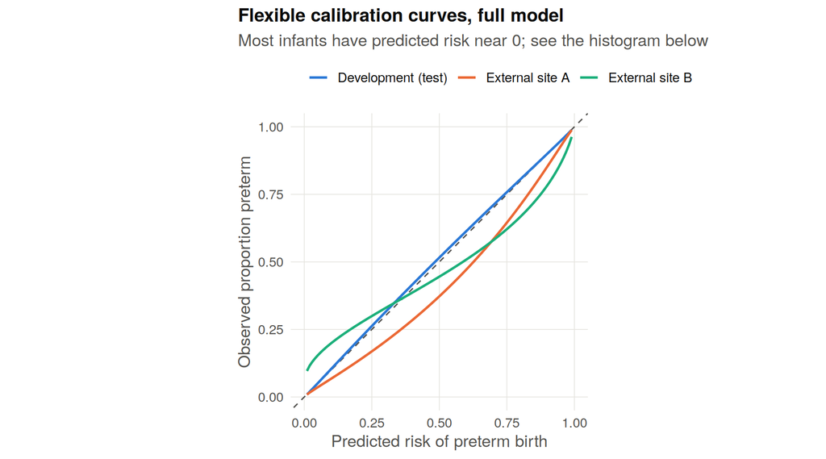

```r
cal_long <- bind_rows(lapply(names(sites), function(s) {
  cbind(cal_curve(res[[s]]$preterm, res[[s]]$p_m3,
                  grid = seq(0.01, 0.99, length.out = 100)),
        site_lab = factor(sites[[s]], levels = sites))
}))
plot_bin_calibration(cal_long, max_p = 1) +
  labs(title = "Flexible calibration curves, full model",
       subtitle = "Most infants have predicted risk near 0; see the histogram below")
```

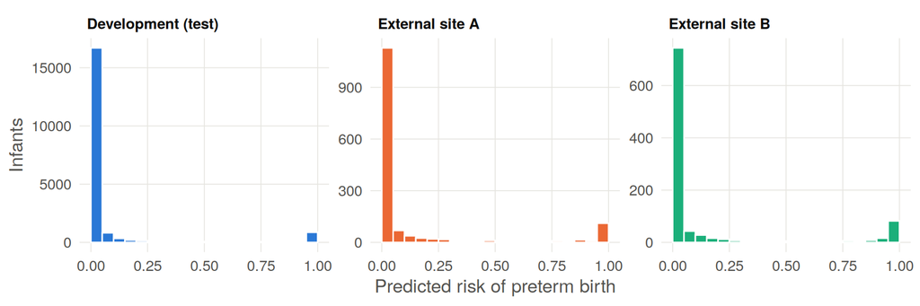

```r
bind_rows(lapply(names(sites), function(s) {
  data.frame(p = res[[s]]$p_m3, site_lab = factor(sites[[s]], levels = sites))
})) |>
  ggplot(aes(p, fill = site_lab)) +
  geom_histogram(binwidth = 0.05, boundary = 0, colour = "white") +
  facet_wrap(~ site_lab, scales = "free_y") +
  scale_fill_manual(values = COL_SITE, guide = "none") +
  labs(x = "Predicted risk of preterm birth", y = "Infants") +
  theme_seminar()
```

- **Site A** has almost the same AUC as the development test set, but it **over-predicts** preterm risk (O/E < 1). The lab shift pushes GA predictions down, so preterm risk goes up. The AUC cannot see this.
- **Site B** appears to **under-predict** (O/E > 1), with a calibration slope well below 1, which would usually suggest overfitting. Here it is mostly the noisy reference standard: late ultrasounds misclassify some term infants as preterm, and the model is “penalised” for correctly calling them term. Check it against the true status:

```r
bin_metrics(res$siteB$preterm_true, res$siteB$p_m3) |>
  select(prevalence, mean_pred, O_E, CITL, cal_slope, AUC) |>
  mutate(across(everything(), \(x) round(x, 3)))
```

| prevalence | mean_pred | O_E | CITL | cal_slope | AUC |
| --- | --- | --- | --- | --- | --- |
| 0.142 | 0.148 | 0.957 | -0.232 | 1.454 | 0.995 |

Against the true status, calibration-in-the-large is close to ideal. The slope is now **above** 1, so the risks are if anything too cautious, because the model also learned from an imperfect reference in development.

## 5.2 Overfitting shows up as a calibration slope below 1

```r
n_pred <- ncol(make_x(res$test[1:2, ], res$models$spec))
ovf <- bind_rows(
  cbind(model = "Full (elastic net, n = 40,000)",
        cont_metrics(res$test$ga_ref, res$test$pred_m3)),
  cbind(model = paste0("Small-n OLS (n = 200, ", n_pred, " predictors)"),
        cont_metrics(res$test$ga_ref, res$test$pred_small)),
  cbind(model = "Random forest",
        cont_metrics(res$test$ga_ref, res$test$pred_rf)))
ovf |> select(model, MAE_wk, within_7d, cal_slope) |>
  mutate(across(where(is.double), \(x) round(x, 2)))
```

| model | MAE_wk | within_7d | cal_slope |
| --- | --- | --- | --- |
| Full (elastic net, n = 40,000) | 0.70 | 0.75 | 1.00 |
| Small-n OLS (n = 200, 67 predictors) | 0.84 | 0.66 | 0.88 |
| Random forest | 0.74 | 0.72 | 1.10 |

- **Slope < 1** (small-n OLS): predictions are **too extreme**, the classic sign of overfitting.
- **Slope > 1** (random forest): predictions are **too compressed** toward the mean. Forests cannot extrapolate beyond the averages of their leaves.

Neither shows up in the MAE alone.

# 6 Clinical usefulness: net benefit

Suppose the model is used to flag infants as **preterm for extra follow-up**. The threshold probability *p*<sub>t</sub> expresses how many false positives you would accept per true positive: *p*<sub>t</sub> = 0.2 means flagging 4 term infants to catch 1 preterm infant is acceptable.

> **Net benefit** = TP/*n* − FP/*n* × *p*<sub>t</sub> / (1 − *p*<sub>t</sub>)

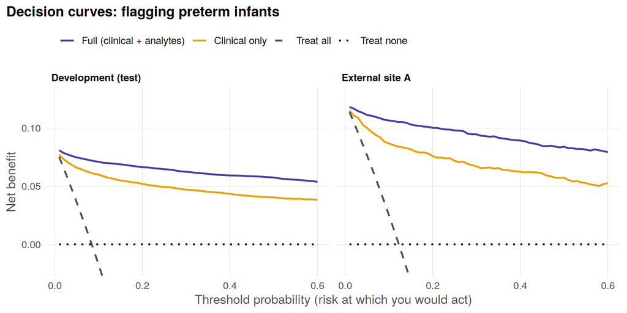

```r
dca_long <- function(d) {
  nb3 <- net_benefit(d$preterm, d$p_m3)
  nb1 <- net_benefit(d$preterm, d$p_m1)
  bind_rows(
    data.frame(threshold = nb3$threshold, net_benefit = nb3$model,
               strategy = "Full (clinical + analytes)"),
    data.frame(threshold = nb1$threshold, net_benefit = nb1$model,
               strategy = "Clinical only"),
    data.frame(threshold = nb3$threshold, net_benefit = nb3$treat_all,
               strategy = "Treat all"),
    data.frame(threshold = nb3$threshold, net_benefit = 0,
               strategy = "Treat none"))
}
dca_both <- bind_rows(
  cbind(dca_long(res$test),  site_lab = "Development (test)"),
  cbind(dca_long(res$siteA), site_lab = "External site A"))
plot_dca(dca_both) + facet_wrap(~ site_lab) +
  labs(title = "Decision curves: flagging preterm infants")
```

A model is useful at a given threshold if its curve sits above **both** “treat all” and “treat none”. The full model adds net benefit over the clinical model across the plausible range of thresholds, in both settings.

# 7 Class imbalance: should we upweight preterm infants?

Preterm birth is uncommon (about 8% here), so a model fitted by least squares spends most of its effort on term infants. In the original metabolic GA models, preterm infants were **upweighted during training** with a graded weight:

> *w* = 1 if GA ≥ 37 weeks; *w* = 1 + (37 − GA) / 1.5 if GA < 37 weeks

so an infant born at 34 weeks counts 3 times, and at 28 weeks 7 times. A common alternative for binary outcomes is **balanced** weighting: each preterm infant counts (1 − prevalence) / prevalence ≈ 11 times. What do these choices do to each metric?

```r
if (file.exists("output/weights.rds")) {
  wfit <- readRDS("output/weights.rds")
} else {
  wfit <- fit_weighted(res)
  saveRDS(wfit, "output/weights.rds")
}
add_weighted_preds <- function(d) {
  x <- make_x(d, res$models$spec)
  pr <- function(f) drop(predict(f, newx = x, s = "lambda.min",
                                 type = "response"))
  d$pred_wt     <- pr(wfit$cont_graded)   # continuous GA, graded weights
  d$pbin_unw    <- pr(wfit$bin_unw)       # direct preterm models
  d$pbin_graded <- pr(wfit$bin_graded)
  d$pbin_bal    <- pr(wfit$bin_bal)
  d
}
for (s in c("test", "siteA")) res[[s]] <- add_weighted_preds(res[[s]])
```

## 7.1 Continuous GA: a trade-off between preterm and term accuracy

```r
ga_band <- function(ga) cut(ga, c(0, 32, 34, 37, 39, 41, 50), right = FALSE,
                            labels = c("<32", "32-33", "34-36", "37-38",
                                       "39-40", "41+"))
res$test |>
  group_by(`Reference GA` = ga_band(ga_ref)) |>
  summarise(n = n(),
            `MAE unweighted` = mean(abs(pred_m3 - ga_ref)),
            `MAE weighted`   = mean(abs(pred_wt - ga_ref)),
            `Bias unweighted` = mean(pred_m3 - ga_ref),
            `Bias weighted`   = mean(pred_wt - ga_ref)) |>
  mutate(across(where(is.double), \(x) round(x, 2)))
```

| Reference GA | n | MAE unweighted | MAE weighted | Bias unweighted | Bias weighted |
| --- | --- | --- | --- | --- | --- |
| <32 | 230 | 0.71 | 0.64 | 0.25 | 0.15 |
| 32-33 | 328 | 0.96 | 0.83 | 0.60 | 0.31 |
| 34-36 | 1131 | 0.96 | 0.86 | 0.73 | 0.48 |
| 37-38 | 6267 | 0.73 | 0.74 | 0.49 | 0.41 |
| 39-40 | 10134 | 0.58 | 0.62 | -0.19 | -0.20 |
| 41+ | 1910 | 1.02 | 1.00 | -0.99 | -0.95 |

```r
d <- res$test
flag <- function(p) c(sensitivity = mean(p[d$preterm == 1] < 37),
                      PPV = mean(d$preterm[p < 37]))
bind_rows(
  cbind(model = "Unweighted", cont_metrics(d$ga_ref, d$pred_m3),
        t(flag(d$pred_m3))),
  cbind(model = "Graded preterm weights", cont_metrics(d$ga_ref, d$pred_wt),
        t(flag(d$pred_wt)))) |>
  select(model, MAE_wk, within_7d, cal_slope, sensitivity, PPV) |>
  mutate(across(where(is.double), \(x) round(x, 3)))
```

| model | MAE_wk | within_7d | cal_slope | sensitivity | PPV |
| --- | --- | --- | --- | --- | --- |
| Unweighted | 0.699 | 0.747 | 0.996 | 0.772 | 0.895 |
| Graded preterm weights | 0.708 | 0.742 | 0.952 | 0.803 | 0.833 |

Here *sensitivity* and *PPV* treat “predicted GA < 37 weeks” as a positive test.

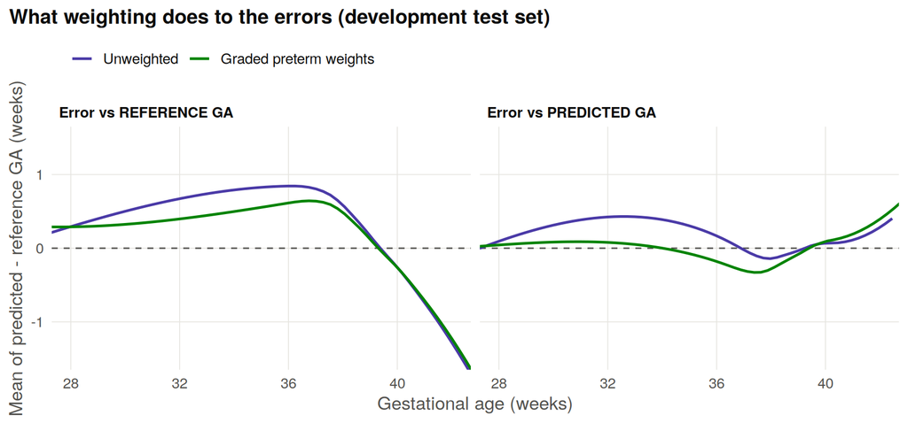

```r
plot_weighting_bias(res$test, c("Unweighted" = "pred_m3",
                                "Graded preterm weights" = "pred_wt")) +
  labs(title = "What weighting does to the errors (development test set)")
```

- Weighting **shrinks the regression-to-the-mean bias** in preterm infants and improves their MAE, at a small cost for term infants. Overall MAE barely moves.
- Seen conditional on the prediction (right), the weighted model **pulls predictions near 37–38 weeks downward**. Infants predicted to be 37–38 weeks are, on average, older than predicted. More infants cross the < 37 line: sensitivity rises and PPV falls.
- The unweighted model was itself slightly miscalibrated in the sparse preterm range (right panel, 31–35 weeks). Weighting makes the model attend to that region and repairs most of it, while creating a smaller distortion just below term. This is a legitimate **choice of loss function** (“errors in preterm infants matter more”), and it should be reported as one.

## 7.2 Binary preterm models: weighting moves the threshold, not the ranking

```r
bin_row <- function(label, p) {
  cbind(model = label,
        bin_metrics(d$preterm, p)[, c("AUC", "O_E", "CITL", "cal_slope")],
        class_metrics(d$preterm, p, 0.5)[, c("sensitivity", "specificity",
                                             "PPV")])
}
d <- res$test
bind_rows(bin_row("Unweighted", d$pbin_unw),
          bin_row("Graded preterm weights", d$pbin_graded),
          bin_row("Balanced weights (x11)", d$pbin_bal)) |>
  mutate(across(where(is.double), \(x) round(x, 3)))
```

| model | AUC | O_E | CITL | cal_slope | sensitivity | specificity | PPV |
| --- | --- | --- | --- | --- | --- | --- | --- |
| Unweighted | 0.981 | 1.007 | 0.028 | 1.002 | 0.760 | 0.993 | 0.910 |
| Graded preterm weights | 0.981 | 0.909 | -0.390 | 0.940 | 0.796 | 0.987 | 0.853 |
| Balanced weights (x11) | 0.981 | 0.492 | -2.364 | 1.022 | 0.915 | 0.935 | 0.564 |

The AUC is **identical**: weighting adds no information about who is preterm. What changes is the **risk scale**. Balanced weighting roughly doubles every predicted risk (O/E ≈ 0.5, CITL ≈ −log 11), so a “0.5” cut-off now behaves like a much lower threshold. The same result comes from simply moving the threshold on the unweighted model:

```r
w <- wfit$w_bal
rbind(
  cbind(model = "Balanced weights, threshold 0.5",
        class_metrics(d$preterm, d$pbin_bal, 0.5)),
  cbind(model = sprintf("Unweighted, threshold 1/(1+%.0f)", w),
        class_metrics(d$preterm, d$pbin_unw, 1 / (1 + w)))) |>
  select(model, sensitivity, specificity, PPV, NPV) |>
  mutate(across(where(is.double), \(x) round(x, 3)))
```

| model | sensitivity | specificity | PPV | NPV |
| --- | --- | --- | --- | --- |
| Balanced weights, threshold 0.5 | 0.915 | 0.935 | 0.564 | 0.992 |
| Unweighted, threshold 1/(1+11) | 0.917 | 0.936 | 0.571 | 0.992 |

```r
# ...and subtracting log(w) on the logit scale undoes the miscalibration
p_corr <- plogis(qlogis(clamp(d$pbin_bal)) - log(w))
bin_metrics(d$preterm, p_corr)[, c("O_E", "CITL", "cal_slope", "AUC")] |>
  round(3)
```

| O_E | CITL | cal_slope | AUC |
| --- | --- | --- | --- |
| 1.009 | 0.034 | 1.022 | 0.981 |

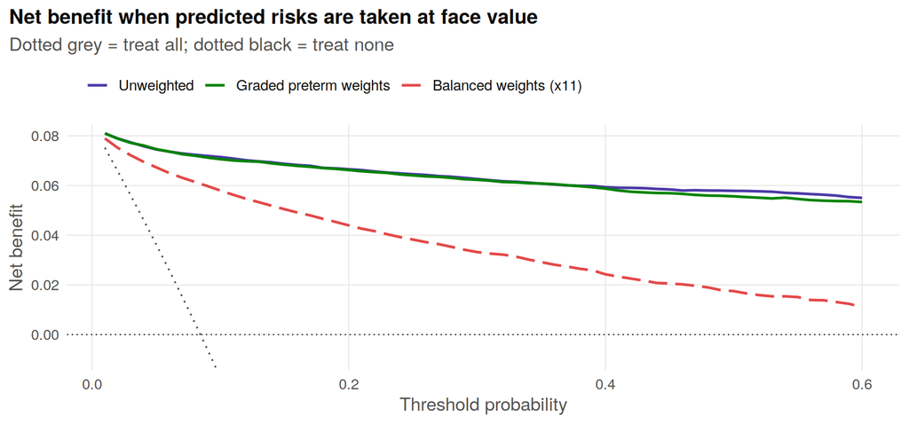

```r
wt_models <- c("Unweighted" = "pbin_unw",
               "Graded preterm weights" = "pbin_graded",
               "Balanced weights (x11)" = "pbin_bal")
nb_w <- bind_rows(lapply(names(wt_models), function(m) {
  nb <- net_benefit(d$preterm, d[[wt_models[[m]]]])
  data.frame(strategy = m, threshold = nb$threshold, net_benefit = nb$model,
             treat_all = nb$treat_all)
}))
nb_w$strategy <- factor(nb_w$strategy, levels = names(wt_models))
ggplot(nb_w, aes(threshold, net_benefit, colour = strategy,
                 linetype = strategy)) +
  geom_line(data = subset(nb_w, strategy == "Unweighted"),
            aes(threshold, treat_all), inherit.aes = FALSE,
            colour = INK2, linetype = "dotted", linewidth = 0.6) +
  geom_hline(yintercept = 0, colour = INK, linetype = "dotted",
             linewidth = 0.4) +
  geom_line(linewidth = 0.9) +
  scale_colour_manual(values = COL_WT) +
  scale_linetype_manual(values = LTY_WT) +
  coord_cartesian(ylim = c(-0.01, 0.08)) +
  labs(title = "Net benefit when predicted risks are taken at face value",
       subtitle = "Dotted grey = treat all; dotted black = treat none",
       x = "Threshold probability", y = "Net benefit") +
  theme_seminar()
```

If the weighted model’s risks are used as if they were real probabilities, it shows **lower net benefit at every threshold**. The model is no worse at ranking; its risks are simply inflated, so each threshold flags too many infants.

**Take-away on class imbalance**

- Rare outcomes do not need to be “fixed” to get a good AUC or good calibration.
- If the concern is missing preterm infants, **choose the decision threshold** (for example with a decision curve) rather than reweighting the data.
- If you do weight, for example as a deliberate loss-function choice for continuous GA, **report calibration** and recalibrate risks before they are used for decisions.
- See van den Goorbergh et al., *JAMIA* 2022, on the harms of class-imbalance corrections for risk prediction.

# 8 Internal and external validation

## 8.1 How optimistic is apparent performance?

Take the small-n model. Its **apparent** performance, measured in the same 200 infants it was fitted on, looks excellent. Bootstrap optimism correction estimates how much of that will disappear, using only the development data:

```r
dev_small <- res$train[res$models$small_rows, ]
X  <- cbind(1, make_x(dev_small, res$models$spec))
y  <- dev_small$ga_ref
fit_ols <- function(X, y) { b <- lm.fit(X, y)$coefficients; b[is.na(b)] <- 0; b }
perf <- function(y, p) c(MAE = mean(abs(y - p)), slope = unname(coef(lm(y ~ p))[2]))

apparent <- perf(y, X %*% fit_ols(X, y))
set.seed(42)
optimism <- rowMeans(replicate(200, {
  i <- sample(nrow(X), replace = TRUE)
  b <- fit_ols(X[i, ], y[i])
  perf(y[i], X[i, ] %*% b) - perf(y, X %*% b)   # boot-apparent - boot-on-original
}))
data.frame(
  estimate = c("Apparent (n = 200)", "Bootstrap optimism-corrected",
               "Actual, independent test set (n = 20,000)"),
  rbind(apparent, apparent - optimism,
        perf(res$test$ga_ref, res$test$pred_small)),
  row.names = NULL) |>
  mutate(across(where(is.double), \(x) round(x, 2)))
```

| estimate | MAE | slope |
| --- | --- | --- |
| Apparent (n = 200) | 0.63 | 1.00 |
| Bootstrap optimism-corrected | 0.94 | 0.78 |
| Actual, independent test set (n = 20,000) | 0.84 | 0.88 |

Apparent performance is badly optimistic. The bootstrap-corrected estimate is much closer to the truth, using only the 200 development infants, which matters most when data are scarce. Here it slightly **over**-corrects: with 67 predictors and 200 infants, no internal validation is precise. The real lesson is that this model should not have been fitted this way in the first place (see sample-size guidance for model development, e.g. Riley et al.).

## 8.2 Updating a model for a new setting

At site A the model is well ranked but shifted. Use **half** of site A to re-estimate the intercept (and slope), then evaluate in the **other half**:

```r
set.seed(7)
iA <- sample(nrow(res$siteA), nrow(res$siteA) / 2)
upd <- res$siteA[iA, ]; evl <- res$siteA[-iA, ]

f_int   <- recal_continuous(upd$ga_ref, upd$pred_m3, slope = FALSE)
f_slope <- recal_continuous(upd$ga_ref, upd$pred_m3, slope = TRUE)
evl$pred_int   <- f_int(evl$pred_m3)
evl$pred_slope <- f_slope(evl$pred_m3)

# preterm risk follows from the updated GA predictions through the same link
risk <- function(pred) predict(link, newdata = data.frame(pred_m3 = pred),
                               type = "response")

version_row <- function(label, pred) {
  cbind(version = label, cont_metrics(evl$ga_ref, pred),
        bin_metrics(evl$preterm, risk(pred))[, c("O_E", "CITL", "AUC")])
}
bind_rows(version_row("Original", evl$pred_m3),
          version_row("Intercept updated", evl$pred_int),
          version_row("Intercept + slope updated", evl$pred_slope)) |>
  select(version, bias_wk, MAE_wk, within_7d, O_E, CITL, AUC) |>
  mutate(across(where(is.double), \(x) round(x, 3)))
```

| version | bias_wk | MAE_wk | within_7d | O_E | CITL | AUC |
| --- | --- | --- | --- | --- | --- | --- |
| Original | -0.255 | 0.761 | 0.709 | 0.882 | -0.539 | 0.98 |
| Intercept updated | 0.038 | 0.728 | 0.719 | 1.039 | 0.172 | 0.98 |
| Intercept + slope updated | 0.038 | 0.728 | 0.719 | 1.045 | 0.195 | 0.98 |

A simple intercept update, estimated from 750 local infants, removes the bias and most of the risk miscalibration. Adding a slope gains little here, because the slope was already close to 1. The AUC does not change: shifting every prediction by the same amount does not change the ranking.

# 9 Take-home checklist

1. **What is the model for?** The intended use decides which metrics matter.
2. **Report discrimination and calibration**, never the AUC alone.
3. **Calibration is judged conditional on the prediction.** Subgroup bias by true outcome is a different question.
4. **Check clinical usefulness** (net benefit) at thresholds that make sense.
5. **Internal validation** (bootstrap, cross-validation) estimates optimism. **External validation** tests transportability, which is a different question.
6. **Interrogate the reference standard** before blaming the model.
7. Poor calibration in a new setting is often **fixable** by updating.
8. **Class imbalance** is handled by choosing thresholds, not by distorting risks. If you weight, report and correct calibration.
9. Report with **TRIPOD+AI** and appraise with **PROBAST+AI**.

# 10 References and further reading

- Hawken S, et al. Development and external validation of machine learning algorithms for postnatal gestational age estimation using clinical data and metabolomic markers. *PLOS ONE* 2023.
- Hawken S, et al. External validation of machine learning models including newborn metabolomic markers for postnatal gestational age estimation in East and South-East Asian infants. *Gates Open Res* 2021.
- Hawken S, et al. Real world external validation of metabolic gestational age assessment in Kenya. *PLOS Glob Public Health* 2022.
- Murphy MSQ, et al. External validation of postnatal gestational age estimation using newborn metabolic profiles in Matlab, Bangladesh. *eLife*
- Van Calster B, et al. Calibration: the Achilles heel of predictive analytics. *BMC Med* 2019.
- van den Goorbergh R, van Smeden M, Timmerman D, Van Calster B. The harm of class imbalance corrections for risk prediction models: illustration and simulation using logistic regression. *J Am Med Inform Assoc* 2022.
- Vickers AJ, Elkin EB. Decision curve analysis: a novel method for evaluating prediction models. *Med Decis Making* 2006.
- Riley RD, Archer L, et al. Evaluation of clinical prediction models (parts 1–3). *BMJ* 2024.
- Collins GS, et al. TRIPOD+AI statement. *BMJ* 2024.